# Week 4. Probabilities and Distributions (I)

# Probability into **R**

이번 주는 데이터를 효율적으로, 그리고 체계적으로 전처리하는 방법에 대해서 살펴보겠습니다. 저번 주에 이어서 전처리 및 데이터 관리를 효율적이고 간편하게 수행하기 위해 `tidyverse` 패키지와 그 패키지에 속하는 다른 패키지들(`tidyverse familiy`), 그리고 함수들을 주로 사용하도록 하겠습니다.

## 패키지 불러오기

```r
library(knitr) # R의 결과를 표로 재구성하는 데 유용한 패키지
library(kableExtra) # knitr의 표 스타일을 보조하는 패키지
library(ggplot2)
library(patchwork)
library(tidyverse)
```

확률 관련 포스팅에서는 몇 가지 간단한 확률을 **R**을 통해서 증명하고(Some simple probability demonstrations), 정규분포(normal distributions)와 이항분포(binomial distributions)로부터 분위(quantiles)를 얻어내는 방법을 살펴보고자 합니다.

여기서는 일단 간단하게 정규분포랑 이항분포, 그리고 독립사건과 종속사건만 간단하게 살펴보겠습니다.

- 분위(Quantiles)에 대해 어떻게 설명할까 고민을 좀 했는데 좋은 블로그 포스팅을 찾아서 참조용으로 링크하겠습니다.
- 링크는 [여기](https://blog.naver.com/sw4r/221026102874)를 보시면 됩니다. Q-Q Plot 설명하면서 Quantile의 정의도 잘 정리해놓으셨습니다.

## 확률이란?

확률모델은 우리가 어떠한 이론-모델을 가지고 있을 때, 어떠한 데이터를 관측할 확률에 대해 알려줍니다. 동전 던지기를 예로 들어보겠습니다. 동전 던지기를 할 때, 우리는 압면을 관측할 확률에 대해서 대강 알고 있습니다. 누구든지 물어보면 0.5의 확률이라고 말할 것입니다. 동전을 던졌을 때, 얻을 수 있는 가능성이 앞면과 뒷면이라는 두 가지밖에 없고 이 동전에 아무런 문제가 없을 때, 그 기대값이 0.5일 것이라는 일종의 이론, 모델을 가지고 있기 때문입니다. 정확히는 동전을 반복해서 던졌을 때(=관측이 반복될 때) 데이터가 어떻게 나타날 것(앞면 뒷면이 반반)이라는 자료생성과정에 관한 이론을 우리가 가지고 있다는 것입니다. 우리가 어떤 모델, 이론을 가지고 있을 때, $Y$라는 결과를 얻을 확률을 아래와 같이 적어보겠습니다.

$$Pr(Y|M) = Pr(\text{데이터}|\text{모델})$$

다음으로는 확률의 종류에 대해서 알아보도록 하겠습니다. 예전에 배우셨던 집합 개념을 조금 떠올리실 필요가 있습니다. 먼저, 사건 `A`와 사건 `B`가 있다고 하겠습니다. 그리고 이 두 사건이 동시에 일어날 확률을 `A`와 `B`에 대한 결합확률(joint probability)이라고 하겠습니다. 집합 기호로 나타내면 $Pr(A\cap B)$로 나타낼 수 있으며, $Pr(A\;\text{and}\;B)$라고도 합니다.

한계확률은 전체 중에서 특정 사건이 발생할 확률을 말합니다. 예를 들어서, 아래와 같은 상황이 있다고 하겠습니다. `A`라는 국가와 `B`라는 국가가 서로 갈등하는 국면에 놓여있는 상황입니다. `A`와 `B` 모두가 싸우기로 결정할 확률은 $Pr(A_{\text{Fight}}\;\cap\;B_{\text{Fight}}) = 0.3$이라고 할 수 있습니다. 반대로 두 국가 모두가 서로 싸움을 회피하고 상대방의 요구에 순응할 확률은 $Pr(A_{\text{Comply}}\;\cap\;B_{\text{Comply}}) = 0.4$입니다. 이 두 경우 모두 결합확률이죠. 그렇다면 `A`가 싸울 한계확률은 얼마일까요? 전체 중에 $A_{\text{Fight}}$일 경우이므로 0.4라고 할 수 있습니다. 마찬가지로 $Pr(A_{\text{Comply}}) = 0.6$이며, 같은 논리로 $Pr(B_{\text{Fight}}, B_{\text{Comply}})$는 각각 0.5, 0.5 라고 할 수 있습니다.

한계확률과 결합확률 (1)

| 구분 | A$_{\text{Fight}}$ | A$_{\text{Comply}}$ | 총합 |
| --- | --- | --- | --- |
| B$_{\text{Fight}}$ | 0.3 | 0.2 | 0.5 |
| B$_{\text{Comply}}$ | 0.1 | 0.4 | 0.5 |
| 총합 | 0.4 | 0.6 | 1 |

그럼 위의 표를 바탕으로 조건부확률(conditional distribution)도 한 번 살펴보겠습니다. 조건부확률이란 한계확률 대비 결합확률의 비율이라고 핤 수 있습니다. `A`와 `B`라는 사건으로 일반화된 진술로 표현하자면, $Pr(A|B) = P(A \cap B)/P(B)$라고 할 수 있으며, 이때 조건부확률은 사건 `B` 일어났을 경우에 `A`라는 사건이 나타날 확률을 의미합니다.

하나 더 살펴보도록 하겠습니다. 유권자들에게 `A`라는 후보에게 투표했는지, 혹은 `B`라는 후보에게 투표했는지 묻고, 동시에 그들이 남성인지 여성인지에 대해 물었다고 해보겠습니다.

한계확률과 결합확률 (2)

| 구분 | A | B | 총합 |
| --- | --- | --- | --- |
| 남성 | 40 | 60 | 100 |
| 여성 | 65 | 35 | 100 |
| 총합 | 105 | 95 | 200 |

이때, 한계확률과 조건부확률, 그리고 결합확률을 각각 살펴보겠습니다.

조건부확률은 한계확률에 대한 조건부 확률의 비율이라고 이해할 수 있습니다:

- $Pr(A|B) = Pr(A, \;B)/Pr(B)$
- $Pr(\text{A}|Female) = Pr(\text{A}, \;\;Female)/Pr(Female)$
- $Pr(\text{A}|Female)/Pr(Female) = 0.325/0.5 = 0.65$

결합확률, 한계확률, 그리고 조건부확률은 앞으로를 개념들을 이해하는 데 중요하니까 머리에 잘 담아두시고, 이제 다음으로 넘어가겠습니다.

## 주사위굴리기 게임!

확률을 공부할 때, 지겹도록 등장하는 놈들이 총 셋이 있습니다. 동전, 카드, 그리고 주사위입니다. 인류는 아마도 이 셋을 만듦으로써 스스로를 괴롭히는 통계학을 발전시켰는지도 모르겠습니다… 일단 주사위 굴리기는 직관적으로 확률과 통계를 이해하기 좋은 방식입니다. 먼저 주사위 하나를 한 번 굴리는 것을 시뮬레이팅하는 함수를 코딩해보겠습니다.

```r
die <- as.integer(runif(1, min=1, max=7))
die
```

```
## [1] 4
```

`die`는 `?runif` 라고 입력하여 살펴보면 `generates random deviates.`라고 기술되어 있는 것을 확인할 수 있습니다. 이어지는 함수를 풀어서 설명하면 다음과 같습니다: > 다음의 결과를 정수의 형태로 저장하라(`as.integer`) $\rightarrow$ 무작위로 다음의 범주 내에서 다른 값을 1번 추출하라 $\rightarrow$ 최소값은 1, 최대값은 6 (1 이상 7미만)을 갖게하라.

그러면 이번에는 두 개의 주사위를 굴려보도록 하겠습니다. 굴리는 횟수는 한 번입니다.

```r
dice <- (as.integer(runif(1, min=1, max=7))) +
  (as.integer(runif(1, min=1, max=7)))
dice
```

```
## [1] 7
```

```r
# 주사위 두 개를 100번 던져보기
dice100 <-  (as.integer(runif(100, min=1, max=7))) +
  (as.integer(runif(100, min=1, max=7)))

dice100 %>% table() %>% kable(col.names = c("Dice", "Freq"))
```

| Dice | Freq |
| --- | --- |
| 2 | 2 |
| 3 | 6 |
| 4 | 7 |
| 5 | 16 |
| 6 | 15 |
| 7 | 12 |
| 8 | 7 |
| 9 | 11 |
| 10 | 11 |
| 11 | 9 |
| 12 | 4 |

```r
# 주사위 두 개를 1,000번 던져보기
dice1000 <-  (as.integer(runif(1000, min=1, max=7))) +
  (as.integer(runif(1000, min=1, max=7)))

dice1000 %>% table() %>% kable(col.names = c("Dice", "Freq"))
```

| Dice | Freq |
| --- | --- |
| 2 | 17 |
| 3 | 60 |
| 4 | 92 |
| 5 | 111 |
| 6 | 157 |
| 7 | 136 |
| 8 | 132 |
| 9 | 119 |
| 10 | 102 |
| 11 | 55 |
| 12 | 19 |

```r
# 주사위 두 개를 100만 번 던져보기
dice10000 <-  (as.integer(runif(1e4, min=1, max=7))) +
  (as.integer(runif(1e4, min=1, max=7)))

dice10000 %>% table() %>% kable(col.names = c("Dice", "Freq"))
```

| Dice | Freq |
| --- | --- |
| 2 | 273 |
| 3 | 558 |
| 4 | 823 |
| 5 | 1113 |
| 6 | 1386 |
| 7 | 1730 |
| 8 | 1456 |
| 9 | 1059 |
| 10 | 811 |
| 11 | 531 |
| 12 | 260 |

이렇게 시뮬레이팅한 세 결과를 히스토그램으로 살펴보겠습니다.

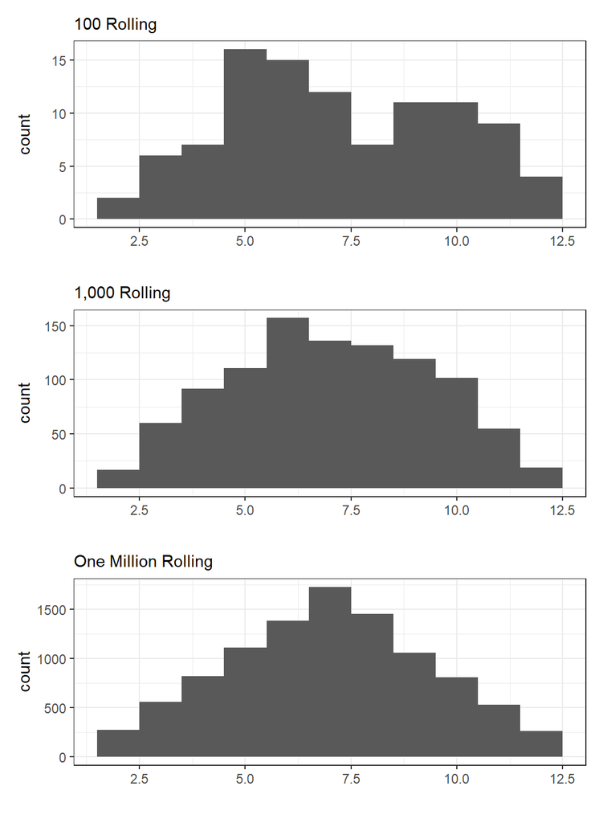

Simulation of Dice Rollings

일단 가시적으로 살펴볼 수 있게 각 코드 이후에 그 결과값의 빈도를 표로 나타내보았습니다. 그리고 그 표를 히스토그램으로 재구성해보았습니다. 역시 `N`이 늘어날 수록 우리(?)가 사랑하는 그 녀석의 모습이 드러나기 시작합니다.

주사위는 1에서 6까지의 한정된 값을 가지고, 두 개를 합쳐서 굴려봐야 2부터 12까지의 한정된(bounded) 값이긴 하지만 이 주사위 굴리기를 통해서 우리는 지난 번 포스팅에서 살펴보았던 것처럼 정규분포(normal distribution)와 표본 크기(n), 혹은 표집(sampling)의 관계를 간접적으로 다시 한 번 살펴볼 수 있습니다.

## 동전 던지기

그럼 이번에는 동전을 한 번 던져보겠습니다. 저는 아직까지 앞면 뒷면 이외에 옆면에도 표기를 지닌 동전을 본 적이 없으니, 여기서의 동전도 앞면과 뒷면이라는 두 개의 값만을 가진다고 가정하겠습니다. 삼면이나 사면을 가진 동전을 보신 분들은 부디 댓글로 알려주시길… 나와라 검은 백조야(김웅진 · 김지희 2012, p.53).

아무튼 앞면과 뒷면이 있는 경우에 그 각각이 나올 확률은 0.5, 0.5라고 할 수 있습니다. `rbinom()`은, randomly [drawn] binomial, 무작위로 이항변수를 추출하라는 함수라고 할 수 있습니다. 백문이 불여일코드.

```r
coin <- rbinom(5, 1, .5)
coin
```

```
## [1] 1 1 1 1 1
```

이어지는 함수를 풀어서 설명하면 다음과 같습니다.: 이항변수로 무작위로 추출하라(`rbinom()`) $\rightarrow$ 5번 추출하라 $\rightarrow$ 최대값은 1 (=최소값은 0) $\rightarrow$ 추출확률은 0.5. 즉, 1이 나올 확률을 50%로 설정하여 무작위로 추출하라는 것입니다. 그럼 이번에는 100개의 동전을 던져보겠습니다.

```r
# 동전 100개 던지기
coin100 <- rbinom(100, 1, .5)
coin100 %>% table() %>% kable(col.names = c("Coin", "Freq"))
```

| Coin | Freq |
| --- | --- |
| 0 | 57 |
| 1 | 43 |

```r
#동전 1000개 던지기
coin1000 <- rbinom(1000, 1, .5)
coin1000 %>%  table() %>% kable(col.names = c("Coin", "Freq"))
```

| Coin | Freq |
| --- | --- |
| 0 | 524 |
| 1 | 476 |

```r
#동전 1000개 던지기
coin10000 <- rbinom(10000, 1, .5)
coin10000 %>%  table() %>% kable(col.names = c("Coin", "Freq"))
```

| Coin | Freq |
| --- | --- |
| 0 | 4969 |
| 1 | 5031 |

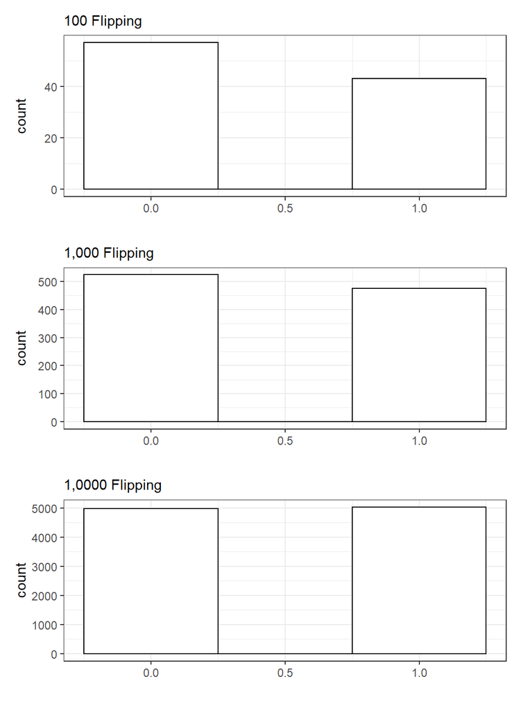

Simulation of Coin Flippings

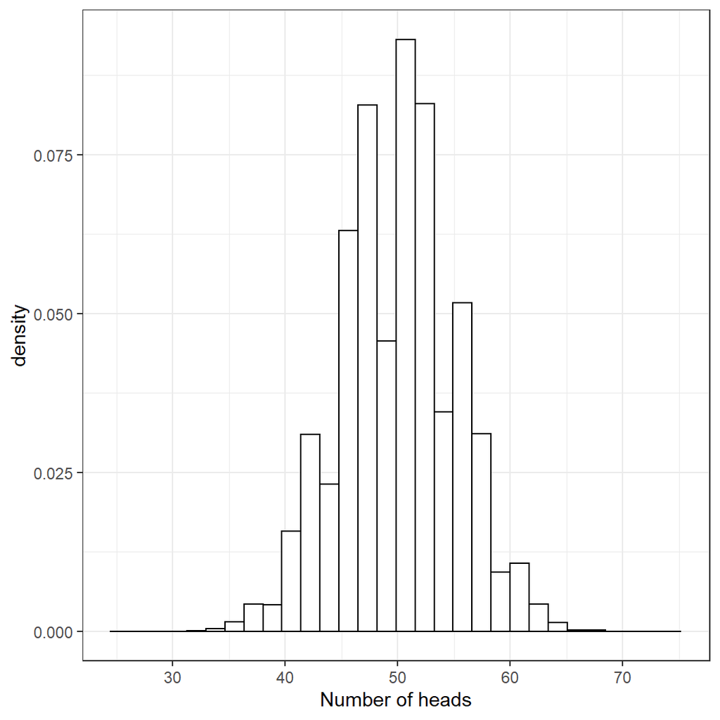

```r
coin1Mx <- rep(NA, 1e6)
for (i in 1:1e6) {
  coin1Mx[i] <- sum(rbinom(100, 1, .5))
}

coin1Mx %>% as_tibble() %>%
  ggplot(aes(value)) +
  geom_histogram(aes(y = ..density..),
                 color = "black", fill = "white") +
  labs(x = "Number of heads") +
  theme_bw()
```

100만 개의 셀을 결측치(`NA`)로 갖는 텅빈 `coinMx`라는 벡터를 만들어보겠습니다. 그리고 `i`가 1에서 100만까지 반복되는 `loop`를 구성합니다. `coin1Mx_1`부터 `coin1Mx_1000000`까지 총 100만개의 `coin1Mx_n`들은 모두 100개의 동전을 던져서 앞면(1)이 나오는 경우의 수를 더한 각각의 값을 가질 것입니다. 따라서 `coin1Mx`는 100만개의 요소를 지닌 벡터입니다.

이 자료를 활용해서 만약 100개를 던졌을 때, 앞면이 60번 나오는 것이 과연 극단적인 확률일지 아니면 무던한 것일지 확인해보겠습니다. 먼저, 60번 이상 앞면이 나온 경우를 세는 함수를 짜보겠습니다.

```r
coin1Mx[coin1Mx > 60] %>% table() %>%
  kable(col.names = c("Head > 60", "Freq."))
```

| Head > 60 | Freq. |
| --- | --- |
| 61 | 7306 |
| 62 | 4547 |
| 63 | 2661 |
| 64 | 1597 |
| 65 | 843 |
| 66 | 429 |
| 67 | 223 |
| 68 | 112 |
| 69 | 46 |
| 70 | 23 |
| 71 | 20 |
| 72 | 3 |
| 73 | 2 |
| 74 | 2 |

앞면이 나오는 빈도가 61번 이상부터는 점차 감소하는 것을 확인할 수 있습니다. 그렇다면 이번에는 앞면이 60번 넘게 나올 확률을 구해보겠습니다.

```r
# 앞면이 60번 넘게 나온 시뮬레이션 횟수/전체 시뮬레이션 횟수
length(coin1Mx[coin1Mx > 60])/length(coin1Mx)
```

```
## [1] 0.017814
```

```r
# 앞면이 60번 넘게 나온 시뮬레이션 횟수를 표로 나타내서 총합을 구한 뒤
# 시뮬레이션 전체 횟수로 나누어 줍니다: 위와 동일합니다.
sum(table(coin1Mx[coin1Mx > 60]))/1e6
```

```
## [1] 0.017814
```

`length()`는 `count()`랑 같은 개념이라고 할 수 있습니다. 전체 `coin1Mx`의 수, 즉 100만 건 중에서 앞면이 60번보다 많이 나온 경우의 수가 어느 정도인지를 계산한 것입니다. 즉, 앞면이 60번보다 더 많이 나올 확률은 매우 작다고 할 수 있습니다다. 앞면이 60번 초과하여 나올 확률은 “평균적” or “일반적”인 것은 아니라는 뜻입니다.

## 독립사건 시뮬레이션

두 개의 독립적인 사건을 시뮬레이션해보겠습니다. 첫 번째 함수는 `rand1`이라는 자료에 최소값 0, 최대값 10 미만의 값을 가지는 100개의 수를 무작위로 담으라는 명령입니다. 두 번째 함수는 정규분포를 따라 평균이 0이고 표준편차가 2의 값을 갖는 분포에서 100개의 값을 무작위로 추출해 rand2라는 자료에 담으라는 명령입니다.

- 일단 보면 `rand2`의 경우, 비록 명령으로 평균을 0으로 하라고 설정했지만 무작위 추출 결과 100개의 값의 평균은 0보다 약간 큰 것을 확인할 수 있습니다.
- 이제 두 값을 각각 $x$축, $y$축으로 설정하여 100개의 값을 좌표에 매칭시킨 그래프로 나타내보겠습니다.

```r
rand1 <- runif(100, min = 0, max = 10)
summary(rand1)
```

```
##     Min.  1st Qu.   Median     Mean  3rd Qu.     Max.
## 0.002237 1.934699 3.781912 4.368364 6.645793 9.808598
```

```r
rand2 <- rnorm(100, mean = 0, sd = 2)
summary(rand2)
```

```
##    Min. 1st Qu.  Median    Mean 3rd Qu.    Max.
## -4.8576 -1.1988  0.2128  0.1494  1.5006  8.1484
```

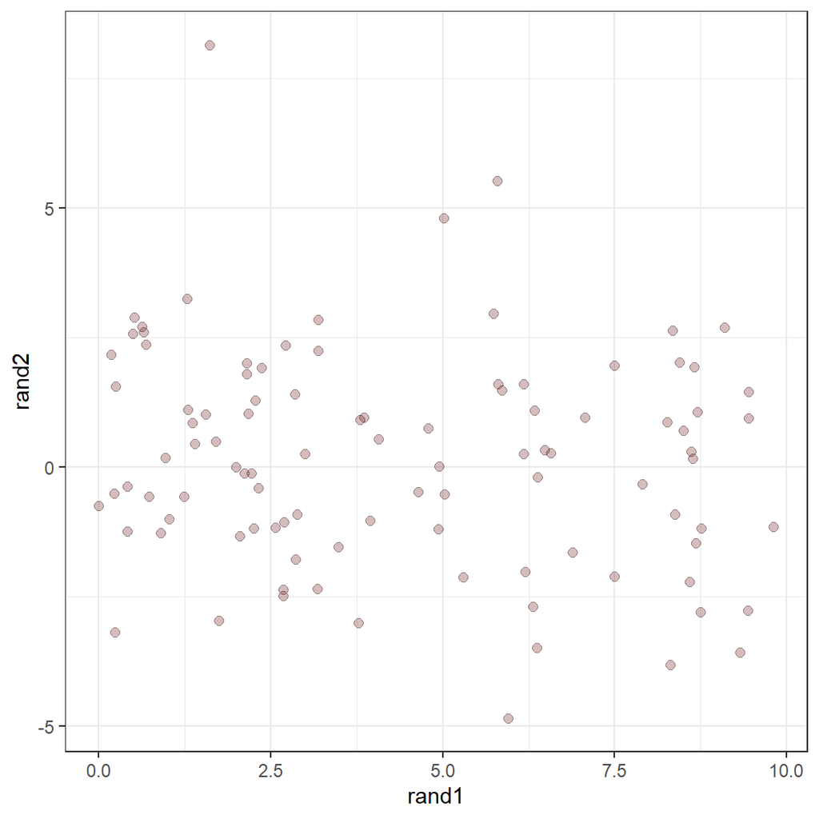

```r
rand.dat <- tibble(rand1 = rand1,
                   rand2 = rand2)
rand.dat %>% ggplot(aes(x = rand1, y = rand2)) +
  geom_point(alpha = 0.3, size = 2, fill = "#752021", shape = 21) +
  theme_bw()
```

결과적으로 이 그래프에서 우리는 `rand1`과 `rand2` 간에는 어떠한 경향성을 발견하기 힘듭니다. 즉, 독립적이라는 것은 두 변수 간에 어떠한 관계를 상정할 수 없다는 것으로 이해할 수 있습니다.

## 종속사건 시뮬레이션

이번에는 두 사건이 종속적 관계에 있는, 즉 한 사건에서의 변화가 다른 사건에 영향을 미치는 경우를 시뮬레이션해 보겠습니다.

`rand3`는 아까 만들어놓은 `rand1`에다가 0.75를 곱해서 4를 더한 100개의 값에다가 사실 상 `rand2`와 같은 방식으로 구한 값을 더하여 구한 자료입니다. 즉, 이 값은 `rand1`의 값에 어떠한 조치를 취하여 얻은 값이므로 `rand1`에 영향을 받은 결과물이라고 할 수 있습니다. 이렇게 구한 `rand3`와 `rand1` 간의 관계를 그래프로 나타내봅시다.

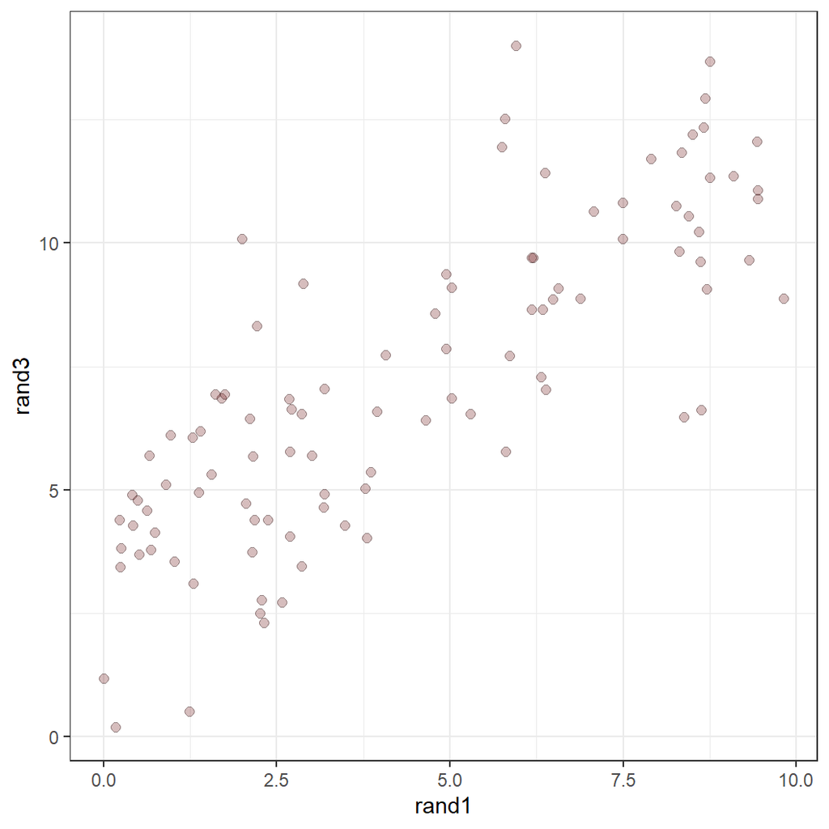

```r
rand.dat <- rand.dat %>%
  mutate(
    rand3 = 4 + 0.75 * rand1 + rnorm(100, mean = 0, sd = 2)
  )

rand.dat %>% ggplot(aes(x = rand1, y = rand3)) +
  geom_point(alpha = 0.3, size = 2, fill = "#752021",  shape = 21) +
  theme_bw()
```

이 그래프의 해석은 나중에 산포도(scatter plot) 및 단순회귀분석(simple regression)을 살펴볼 때 다시 한 번 다룰 것입니다. 일단 여기서는 `rand1`이 증가할 때, `rand3`도 증가세를 보이는—둘의 인과적 관계는 확인할 수 없지만 아무튼—양(positive)의 관계를 보이고 있다는 것을 알 수 있습니다.

`cor(rand1, rand3)`로 두 변수 간의 상관계수를 구해보면[^1], 양수의 기울기를 얻게 됩니다.

이번에는 보다 더 불확실성을 가지는 종속사건의 관계를 시뮬레이션해보겠습니다. 여기서 말하는 불확실성은 더 큰 표준편차를 의미합니다.

- 표준편차가 평균에서 각 관측치가 떨어져 있는 거리의 평균이라고 할 때,
- 표준편차 값이 크다는 것은 개별 값들이 평균에서 더 넓게 분포해 있다는 것을 의미합니다.

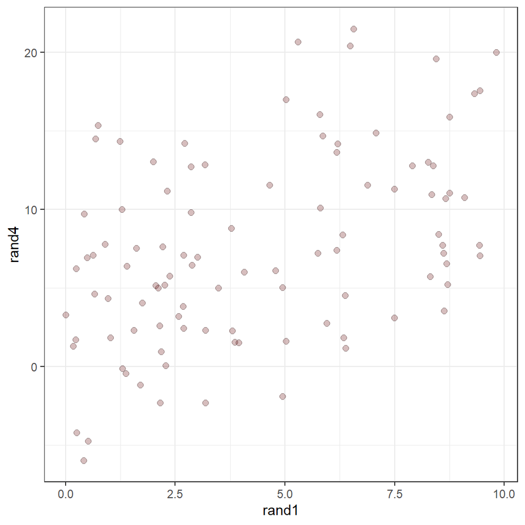

```r
rand.dat <- rand.dat %>%
  mutate(
    rand4 = 4 + 0.75 * rand1 + rnorm(100, mean = 0, sd = 5)
  )

rand.dat %>% ggplot(aes(x = rand1, y = rand4)) +
  geom_point(alpha = 0.3, size = 2, fill = "#752021", shape = 21) +
  theme_bw()
```

```r
cor(rand.dat$rand1, rand.dat$rand4)
```

```
## [1] 0.4477527
```

```r
## 데이터 프레임을 가지고 상관관계를 구하는 방법: corrr 패키지
## install.packages("corrr")
library(corrr)
rand.dat %>% select(rand1, rand4) %>% correlate(quiet = T) %>%
  kable(col.names = c("Variables", "rand1", "rand4"), digits = 3)
```

| Variables | rand1 | rand4 |
| --- | --- | --- |
| rand1 | NA | 0.448 |
| rand4 | 0.448 | NA |

`rand1`과 `rand4`의 산포도는 좀 더 넓게 퍼진 모양새를 보이고 둘의 상관관계는 식에서 상정한 0.75라는 기울기보다 더 낮아지는 것을 확인할 수 있습니다.

[^1]: 뒤의 `rnorm()`을 이용하여 무작위로 생성한 100개의 값을 구했기 때문에, 이 결과는 구할 때마다 달라질 것입니다.